# PROBLEM STATEMENT

### TO DEVELOP AN APPLICATION TO HELPS TO IDENTIFY POTENTIAL LOAN DEFAULT BY FINANCIAL INSTITUTIONS

```python
import pandas as pd
import numpy as np
from scipy.stats import mstats
import seaborn as sns
import matplotlib.pyplot as plt
from scipy.stats import f_oneway
from sklearn import linear_model
from sklearn.metrics import accuracy_score
```

## Undrstanding the data

### Our dataset was gotten from : https://www.kaggle.com/datasets/architsharma01/loan-approval-prediction-dataset.

### The loan approval dataset is a collection of financial records and associated information used to determine the eligibility of individuals or organizations for obtaining loans from a lending institution. It includes various factors such as cibil score, income, employment status, loan term, loan amount, assets value, and loan status. Thanks to Arcadio from our class who pointed me to the right direction in obtainingthis dataset, I also drew some inspiration from your work.

```python
loan_data = pd.read_csv("C:\courses_conestoga\courses_conestoga\CSCN8010-LAB_RAN\PROJECT8010\loan_approval_dataset.csv")
loan_data.head(5)
```

|  | loan_id | no_of_dependents | education | self_employed | income_annum | loan_amount | loan_term | cibil_score | residential_assets_value | commercial_assets_value | luxury_assets_value | bank_asset_value | loan_status |
| --- | --- | --- | --- | --- | --- | --- | --- | --- | --- | --- | --- | --- | --- |
| 0 | 1 | 2 | Graduate | No | 9600000 | 29900000 | 12 | 778 | 2400000 | 17600000 | 22700000 | 8000000 | Approved |
| 1 | 2 | 0 | Not Graduate | Yes | 4100000 | 12200000 | 8 | 417 | 2700000 | 2200000 | 8800000 | 3300000 | Rejected |
| 2 | 3 | 3 | Graduate | No | 9100000 | 29700000 | 20 | 506 | 7100000 | 4500000 | 33300000 | 12800000 | Rejected |
| 3 | 4 | 3 | Graduate | No | 8200000 | 30700000 | 8 | 467 | 18200000 | 3300000 | 23300000 | 7900000 | Rejected |
| 4 | 5 | 5 | Not Graduate | Yes | 9800000 | 24200000 | 20 | 382 | 12400000 | 8200000 | 29400000 | 5000000 | Rejected |

```python
#get the size of dataframe
missing_values = loan_data.isnull().sum()
print ("Rows     : " , loan_data.shape[0])  #get number of rows/observations
print ("Columns  : " , loan_data.shape[1]) #get number of columns
print(missing_values)
```

```
Rows     :  4269
Columns  :  13
loan_id                      0
 no_of_dependents            0
 education                   0
 self_employed               0
 income_annum                0
 loan_amount                 0
 loan_term                   0
 cibil_score                 0
 residential_assets_value    0
 commercial_assets_value     0
 luxury_assets_value         0
 bank_asset_value            0
 loan_status                 0
dtype: int64
```

```python
# Summary statistics for numerical features
summary_stats = loan_data.describe()

# Display the summary statistics
print(summary_stats)
```

```
           loan_id   no_of_dependents   income_annum   loan_amount  \
count  4269.000000        4269.000000   4.269000e+03  4.269000e+03
mean   2135.000000           2.498712   5.059124e+06  1.513345e+07
std    1232.498479           1.695910   2.806840e+06  9.043363e+06
min       1.000000           0.000000   2.000000e+05  3.000000e+05
25%    1068.000000           1.000000   2.700000e+06  7.700000e+06
50%    2135.000000           3.000000   5.100000e+06  1.450000e+07
75%    3202.000000           4.000000   7.500000e+06  2.150000e+07
max    4269.000000           5.000000   9.900000e+06  3.950000e+07

         loan_term   cibil_score   residential_assets_value  \
count  4269.000000   4269.000000               4.269000e+03
mean     10.900445    599.936051               7.472617e+06
std       5.709187    172.430401               6.503637e+06
min       2.000000    300.000000              -1.000000e+05
25%       6.000000    453.000000               2.200000e+06
50%      10.000000    600.000000               5.600000e+06
75%      16.000000    748.000000               1.130000e+07
max      20.000000    900.000000               2.910000e+07

        commercial_assets_value   luxury_assets_value   bank_asset_value
count              4.269000e+03          4.269000e+03       4.269000e+03
mean               4.973155e+06          1.512631e+07       4.976692e+06
std                4.388966e+06          9.103754e+06       3.250185e+06
min                0.000000e+00          3.000000e+05       0.000000e+00
25%                1.300000e+06          7.500000e+06       2.300000e+06
50%                3.700000e+06          1.460000e+07       4.600000e+06
75%                7.600000e+06          2.170000e+07       7.100000e+06
max                1.940000e+07          3.920000e+07       1.470000e+07
```

### EXPLPRATORY DATA ANALYSIS

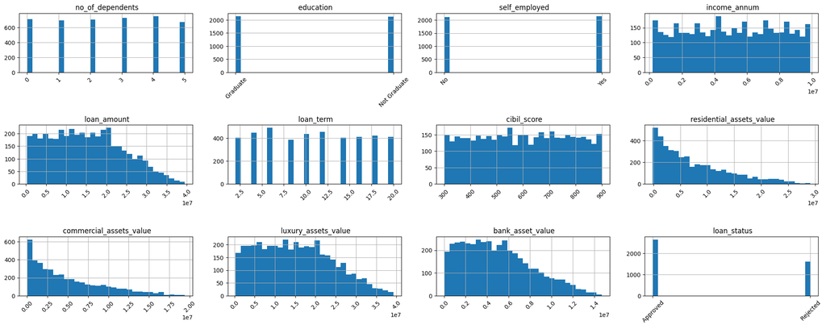

```python
# Drop the first column (it is an index or ID column)
loan_data = loan_data.drop(loan_data.columns[0], axis=1)

# Get the columns of the DataFrame
columns = loan_data.columns

# Adjusting the figure size
plt.figure(figsize=(20, 10))

# Loop and subplot grid based on the new number of columns
for i, column in enumerate(columns, 1):
    plt.subplot(4, 4, i)  # Adjusting the grid size
    if column == 'loan_status':  # Plotting distribution for the target variable
        loan_data[column].value_counts().plot(kind='bar', color=['green', 'red'])
        plt.title('Distribution of Loan Status')
    else:  # Plotting distribution for other features
        loan_data[column].hist(bins=30)  # Adjusting the number of bins as needed
        plt.title(column)
    plt.xticks(rotation=45)  # Rotating x-axis labels for better readability

plt.tight_layout()
plt.show()
```

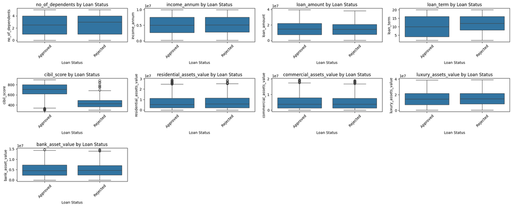

```python
import pandas as pd
import matplotlib.pyplot as plt
import seaborn as sns

# Assuming loan_data is your DataFrame containing the loan data

# Remove leading and trailing spaces from column names
loan_data.columns = loan_data.columns.str.strip()

if 'loan_status' in loan_data.columns:
    # Filter numerical columns for box plots
    numerical_columns = loan_data.select_dtypes(include=['int64', 'float64']).columns

    # Check if there are numerical columns available for plotting
    if len(numerical_columns) > 0:
        # Adjusting the figure size
        plt.figure(figsize=(20, 10))

        # Loop and subplot grid based on the number of numerical columns
        for i, column in enumerate(numerical_columns, 1):
            plt.subplot(4, 4, i)  # Adjusting the grid size
            sns.boxplot(x='loan_status', y=column, data=loan_data)
            plt.title(f'{column} by Loan Status')
            plt.xlabel('Loan Status')
            plt.ylabel(column)
            plt.xticks(rotation=45)  # Rotating x-axis labels for better readability

        plt.tight_layout()
        plt.show()
    else:
        print("No numerical columns found for plotting.")
else:
    print("'loan_status' column not found in the DataFrame.")
```

# observations

### Notice the boxplots for loan term by status and CIBIL_score by status. You will see they significantly differ from the other boxplots. This is an indicator that these features could be of interest to our task.

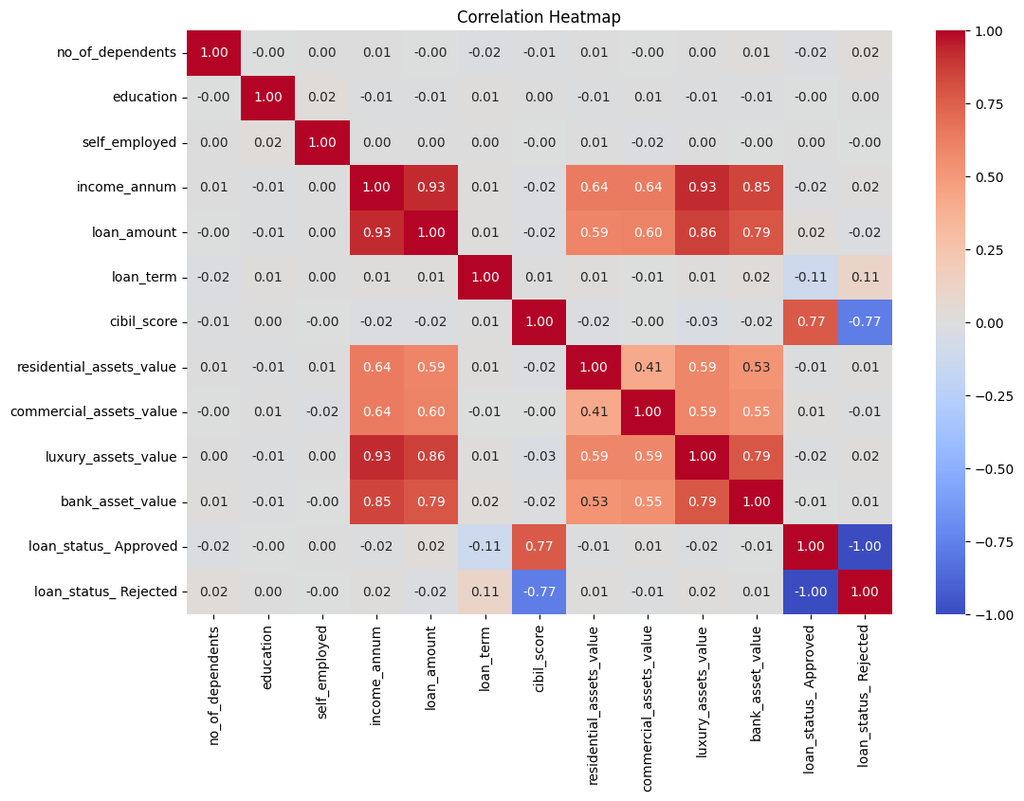

```python
import pandas as pd
import seaborn as sns
import matplotlib.pyplot as plt
from sklearn.preprocessing import LabelEncoder

# Copy the DataFrame to avoid modifying the original data
loan_data_encoded = loan_data.copy()

label_encoder = LabelEncoder()
# Apply one-hot encoding to the "loan_status" column
loan_data_encoded = pd.get_dummies(loan_data, columns=['loan_status'], drop_first=False)

# Apply label encoding to other categorical columns
loan_data_encoded[['education', 'self_employed']] = loan_data_encoded[['education', 'self_employed']].apply(lambda x: label_encoder.fit_transform(x))

# Plot heatmap to show correlation
plt.figure(figsize=(12, 8))
sns.heatmap(loan_data_encoded.corr(), annot=True, cmap='coolwarm', fmt=".2f")
plt.title('Correlation Heatmap')
plt.show()
```

### observations:

### Again we see in this pearson heatmap that the features with the highest correlation to loan_status is CIBIL_score (0.77) and loan_term(0.11).

### MULTIVARIATE ANALYSIS

```python
from scipy.stats import f_oneway

# Define the categorical variable you want to analyze
categorical_variable = 'loan_status'

# Define the numeric features you want to analyze
numeric_features = ['income_annum', 'loan_amount', 'loan_term', 'cibil_score', 'residential_assets_value', 'commercial_assets_value', 'luxury_assets_value', 'bank_asset_value']

# Perform ANOVA for each numeric feature
for feature in numeric_features:
    # Extract the data for each category in the categorical variable
    categories = [loan_data[feature][loan_data[categorical_variable] == category] for category in loan_data[categorical_variable].unique()]

    # Perform ANOVA
    f_statistic, p_value = f_oneway(*categories)

    # Print results
    print(f"ANOVA results for {feature}:")
    print(f"F-statistic: {f_statistic}")
    print(f"P-value: {p_value}\n")
```

```
ANOVA results for income_annum:
F-statistic: 0.984668834796744
P-value: 0.3211051240705809

ANOVA results for loan_amount:
F-statistic: 1.1131763752980253
P-value: 0.2914522504511804

ANOVA results for loan_term:
F-statistic: 55.22545796738935
P-value: 1.2911854638297956e-13

ANOVA results for cibil_score:
F-statistic: 6235.054590534215
P-value: 0.0

ANOVA results for residential_assets_value:
F-statistic: 0.880876699288107
P-value: 0.34801479256209944

ANOVA results for commercial_assets_value:
F-statistic: 0.2901515930863556
P-value: 0.5901515011087077

ANOVA results for luxury_assets_value:
F-statistic: 1.0207282810218434
P-value: 0.3124036068558353

ANOVA results for bank_asset_value:
F-statistic: 0.19606590791358344
P-value: 0.6579376940179931
```

### Inference: Based on the ANOVA results, loan term and CIBIL score show statistically significant differences in means between approved and rejected loans, confirming they are the most important predictors of loan approval status. The other numerical features do not show significant differences in means.

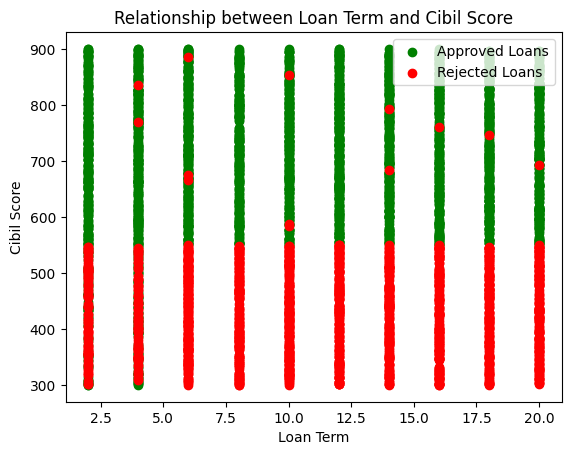

```python
# Filter the DataFrame for approved and rejected loans
approved_loans = loan_data_encoded[loan_data_encoded['loan_status_ Approved'] == 1]
rejected_loans = loan_data_encoded[loan_data_encoded['loan_status_ Rejected'] == 1]

# Plot the scatter for approved loans
plt.scatter(approved_loans['loan_term'], approved_loans['cibil_score'], label='Approved Loans', color='green')

# Plot the scatter for rejected loans
plt.scatter(rejected_loans['loan_term'], rejected_loans['cibil_score'], label='Rejected Loans', color='red')

# Add labels and title
plt.xlabel('Loan Term')
plt.ylabel('Cibil Score')
plt.title('Relationship between Loan Term and Cibil Score')
plt.legend()
plt.show()
```

### MODEL TRAINING

```python
from sklearn.model_selection import train_test_split, cross_val_score
from sklearn.preprocessing import StandardScaler
from sklearn.linear_model import LogisticRegression
from sklearn.ensemble import RandomForestClassifier
from sklearn.pipeline import Pipeline
import pickle

# Define features and target variable
X = loan_data_encoded.drop(columns=['loan_status_ Approved', 'loan_status_ Rejected'])
y = loan_data_encoded['loan_status_ Approved']

# Split the data into train, validation, and test sets (70%, 15%, 15%)
X_train, X_temp, y_train, y_temp = train_test_split(X, y, test_size=0.3, random_state=42)
X_val, X_test, y_val, y_test = train_test_split(X_temp, y_temp, test_size=0.5, random_state=42)

scaler = StandardScaler()
X_scaled = scaler.fit_transform(X)

# Save the scaler using pickle
with open('scaler.pkl', 'wb') as scaler_file:
    pickle.dump(scaler, scaler_file)

logistic_model = LogisticRegression()
random_forest_model = RandomForestClassifier()

# Create pipeline for logistic regression
logistic_pipeline = Pipeline([('scaler', scaler), ('logistic', logistic_model)])

# Create pipeline for random forest
random_forest_pipeline = Pipeline([('scaler', scaler), ('random_forest', random_forest_model)])

# Train and save the logistic regression model
logistic_pipeline.fit(X_train, y_train)
with open('logistic_regression_model.pkl', 'wb') as model_file:
    pickle.dump(logistic_pipeline, model_file)

# Train and save the random forest model
random_forest_pipeline.fit(X_train, y_train)
with open('random_forest_model.pkl', 'wb') as model_file:
    pickle.dump(random_forest_pipeline, model_file)

# Perform cross-validation to monitor and save the best model
logistic_scores = cross_val_score(logistic_pipeline, X_train, y_train, cv=5, scoring='accuracy')
random_forest_scores = cross_val_score(random_forest_pipeline, X_train, y_train, cv=5, scoring='accuracy')

best_logistic_model = logistic_pipeline if logistic_scores.mean() > random_forest_scores.mean() else random_forest_pipeline

# Save the best model using pickle
with open('best_model.pkl', 'wb') as model_file:
    pickle.dump(best_logistic_model, model_file)

# Load the saved models
with open('logistic_regression_model.pkl', 'rb') as model_file:
    logistic_pipeline = pickle.load(model_file)

with open('random_forest_model.pkl', 'rb') as model_file:
    random_forest_pipeline = pickle.load(model_file)

with open('best_model.pkl', 'rb') as model_file:
    best_model = pickle.load(model_file)

# Predictions on validation set
logistic_val_predictions = logistic_pipeline.predict(X_val)
random_forest_val_predictions = random_forest_pipeline.predict(X_val)
best_model_val_predictions = best_model.predict(X_val)

# Accuracy scores on validation set
logistic_val_accuracy = accuracy_score(y_val, logistic_val_predictions)
random_forest_val_accuracy = accuracy_score(y_val, random_forest_val_predictions)
best_model_val_accuracy = accuracy_score(y_val, best_model_val_predictions)

print("Accuracy on Validation Set:")
print(f"Logistic Regression: {logistic_val_accuracy:.4f}")
print(f"Random Forest: {random_forest_val_accuracy:.4f}")
print(f"Best Model (Cross-Validated): {best_model_val_accuracy:.4f}")
```

```
Accuracy on Validation Set:
Logistic Regression: 0.9016
Random Forest: 0.9812
Best Model (Cross-Validated): 0.9812
```

```
Accuracy on Test Set:
Logistic Regression: 0.9048
Random Forest: 0.9782
Best Model (Cross-Validated): 0.9782
```

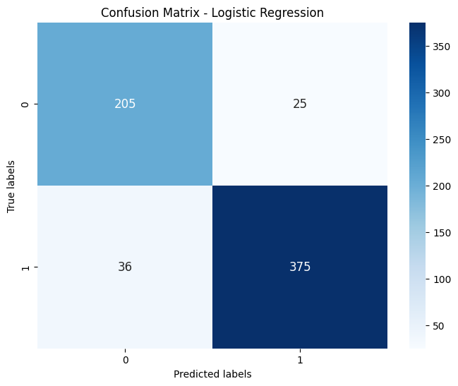

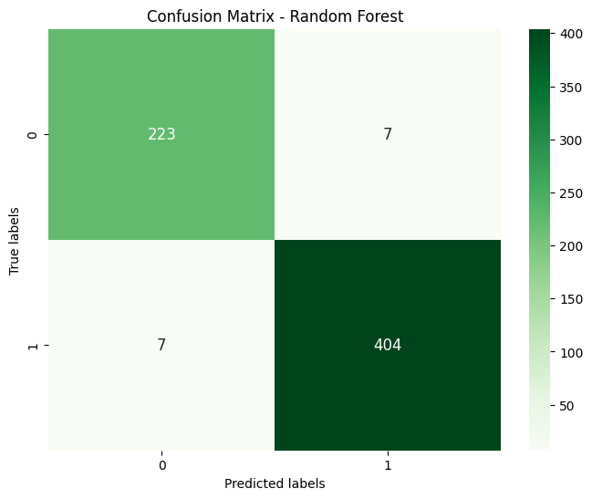

```python
from sklearn.metrics import confusion_matrix
import seaborn as sns

# Predictions on test set
logistic_test_predictions = logistic_pipeline.predict(X_test)
random_forest_test_predictions = random_forest_pipeline.predict(X_test)
best_model_test_predictions = best_model.predict(X_test)

# Accuracy scores on test set
logistic_test_accuracy = accuracy_score(y_test, logistic_test_predictions)
random_forest_test_accuracy = accuracy_score(y_test, random_forest_test_predictions)
best_model_test_accuracy = accuracy_score(y_test, best_model_test_predictions)

print("Accuracy on Test Set:")
print(f"Logistic Regression: {logistic_test_accuracy:.4f}")
print(f"Random Forest: {random_forest_test_accuracy:.4f}")
print(f"Best Model (Cross-Validated): {best_model_test_accuracy:.4f}")

# Confusion matrix for logistic regression
logistic_conf_matrix = confusion_matrix(y_test, logistic_test_predictions)

# Confusion matrix for random forest
random_forest_conf_matrix = confusion_matrix(y_test, random_forest_test_predictions)


# Plot confusion matrix for logistic regression
plt.figure(figsize=(8, 6))
sns.heatmap(logistic_conf_matrix, annot=True, cmap='Blues', fmt='g', annot_kws={"fontsize":12})
plt.xlabel('Predicted labels')
plt.ylabel('True labels')
plt.title('Confusion Matrix - Logistic Regression')
plt.show()

# Plot confusion matrix for random forest
plt.figure(figsize=(8, 6))
sns.heatmap(random_forest_conf_matrix, annot=True, cmap='Greens', fmt='g', annot_kws={"fontsize":12})
plt.xlabel('Predicted labels')
plt.ylabel('True labels')
plt.title('Confusion Matrix - Random Forest')
plt.show()
```

### Overall, the analysis provides valuable insights into the factors influencing loan approval decisions and lays the foundation for building robust predictive models in the lending domain.